# **Atividade 5: Feature Importance**

#### Tópicos Avançados em IC 2 - 2024.2

#### Universidade Federal de Pernambuco (UFPE)

**Aluna:** Bruna Zamith Santos

**Professor:** Dr. Ricardo Prudêncio

**Data:** 09/09/2024

- **1. Introdução**
- **2. Bibliotecas**
- **3. Conjunto de Dados**
- **4. Modelos Gerais (1)**
  - **4.1. KNN**
  - **4.2. Árvore de Decisão**
  - **4.3. Random Forest**
- **5. Modelos Específicos de Gênero (2)**
  - **5.1. KNN**
  - **5.2. Árvore de Decisão**
  - **5.3. Random Forest**

# 1. Introdução

*Voltar à Tabela de Conteúdos*

Este notebook visa resolver a atividade proposta, com o seguinte enunciado:

> 1. Usando os algoritmos kNN, Random Forest e Decision Trees, construa um modelo de classificação para o conjunto Statlog Heart e compute PFI para um conjunto de teste.
> 2. Escolha um dos modelos dos passo 1. Agora crie um gráfico PFI para cada gênero. Separe o conjunto de exemplos de teste por gênero e então executar o PFI uma vez para cada subconjunto de teste separado. Verificar as diferenças entre as variáveis consideradas importantes para cada gênero.

# 2. Bibliotecas

*Voltar à Tabela de Conteúdos*

```python
# Descomente a linha a seguir, se for rodar no seu computador!

#!pip3 install matplotlib numpy pandas scikit-learn
```

```python
from IPython.display import HTML

import matplotlib.pyplot as plt

import numpy as np

import pandas as pd

from sklearn.ensemble import RandomForestClassifier
from sklearn.inspection import permutation_importance
from sklearn.metrics import classification_report
from sklearn.model_selection import train_test_split
from sklearn.neighbors import KNeighborsClassifier
from sklearn.preprocessing import StandardScaler
from sklearn.tree import DecisionTreeClassifier
```

```python
def plot_permutation_importance(clf, X, y, ax):
    result = permutation_importance(clf, X, y, n_repeats=10, random_state=42, n_jobs=2)
    perm_sorted_idx = result.importances_mean.argsort()

    ax.boxplot(
        result.importances[perm_sorted_idx].T,
        vert=False,
        labels=X.columns[perm_sorted_idx],
    )
    ax.axvline(x=0, color="k", linestyle="--")
    return ax
```

# 3. Conjunto de Dados

*Voltar à Tabela de Conteúdos*

A conjunto de dados, provido pelo professor, é o *"Statlog (Heart)"*, do UCI ([link](https://archive.ics.uci.edu/dataset/145/statlog+heart)).

```python
df = pd.read_csv('statlog-heart-dataset.csv', sep=',')
```

```python
df.info()
```

```
<class 'pandas.core.frame.DataFrame'>
RangeIndex: 270 entries, 0 to 269
Data columns (total 14 columns):
 #   Column                Non-Null Count  Dtype
---  ------                --------------  -----
 0   age                   270 non-null    int64
 1   sex                   270 non-null    int64
 2   chest                 270 non-null    int64
 3   pressure              270 non-null    int64
 4   cholestoral           270 non-null    int64
 5   bloodsugar            270 non-null    int64
 6   electrocardiographic  270 non-null    int64
 7   heartRate             270 non-null    int64
 8   exInducedAngina       270 non-null    int64
 9   oldpeak               270 non-null    float64
 10  slope                 270 non-null    int64
 11  numMajorVessels       270 non-null    int64
 12  thal                  270 non-null    int64
 13  class                 270 non-null    object
dtypes: float64(1), int64(12), object(1)
memory usage: 29.7+ KB
```

```python
df.head()
```

|  | age | sex | chest | pressure | cholestoral | bloodsugar | electrocardiographic | heartRate | exInducedAngina | oldpeak | slope | numMajorVessels | thal | class |
| --- | --- | --- | --- | --- | --- | --- | --- | --- | --- | --- | --- | --- | --- | --- |
| 0 | 70 | 1 | 4 | 130 | 322 | 0 | 2 | 109 | 0 | 2.4 | 2 | 3 | 3 | yes |
| 1 | 57 | 1 | 2 | 124 | 261 | 0 | 0 | 141 | 0 | 0.3 | 1 | 0 | 7 | yes |
| 2 | 56 | 1 | 3 | 130 | 256 | 1 | 2 | 142 | 1 | 0.6 | 2 | 1 | 6 | yes |
| 3 | 59 | 1 | 4 | 110 | 239 | 0 | 2 | 142 | 1 | 1.2 | 2 | 1 | 7 | yes |
| 4 | 60 | 1 | 4 | 140 | 293 | 0 | 2 | 170 | 0 | 1.2 | 2 | 2 | 7 | yes |

```python
df.describe()
```

|  | age | sex | chest | pressure | cholestoral | bloodsugar | electrocardiographic | heartRate | exInducedAngina | oldpeak | slope | numMajorVessels | thal |
| --- | --- | --- | --- | --- | --- | --- | --- | --- | --- | --- | --- | --- | --- |
| count | 270.000000 | 270.000000 | 270.000000 | 270.000000 | 270.000000 | 270.000000 | 270.000000 | 270.000000 | 270.000000 | 270.00000 | 270.000000 | 270.000000 | 270.000000 |
| mean | 54.433333 | 0.677778 | 3.174074 | 131.344444 | 249.659259 | 0.148148 | 1.022222 | 149.677778 | 0.329630 | 1.05000 | 1.585185 | 0.670370 | 4.696296 |
| std | 9.109067 | 0.468195 | 0.950090 | 17.861608 | 51.686237 | 0.355906 | 0.997891 | 23.165717 | 0.470952 | 1.14521 | 0.614390 | 0.943896 | 1.940659 |
| min | 29.000000 | 0.000000 | 1.000000 | 94.000000 | 126.000000 | 0.000000 | 0.000000 | 71.000000 | 0.000000 | 0.00000 | 1.000000 | 0.000000 | 3.000000 |
| 25% | 48.000000 | 0.000000 | 3.000000 | 120.000000 | 213.000000 | 0.000000 | 0.000000 | 133.000000 | 0.000000 | 0.00000 | 1.000000 | 0.000000 | 3.000000 |
| 50% | 55.000000 | 1.000000 | 3.000000 | 130.000000 | 245.000000 | 0.000000 | 2.000000 | 153.500000 | 0.000000 | 0.80000 | 2.000000 | 0.000000 | 3.000000 |
| 75% | 61.000000 | 1.000000 | 4.000000 | 140.000000 | 280.000000 | 0.000000 | 2.000000 | 166.000000 | 1.000000 | 1.60000 | 2.000000 | 1.000000 | 7.000000 |
| max | 77.000000 | 1.000000 | 4.000000 | 200.000000 | 564.000000 | 1.000000 | 2.000000 | 202.000000 | 1.000000 | 6.20000 | 3.000000 | 3.000000 | 7.000000 |

```python
df['class'].value_counts()
```

```
class
no     150
yes    120
Name: count, dtype: int64
```

```python
df['class'] = df['class'].map({'no': 0, 'yes': 1})
df.shape
```

```
(270, 14)
```

# 4. Modelos Gerais (1)

*Voltar à Tabela de Conteúdos*

```python
X = df.drop(columns=['class'])
y = df['class']
```

```python
X_train, X_test, y_train, y_test = train_test_split(X, y, test_size=0.25, random_state=42)
```

```python
scaler = StandardScaler()
X_train_scaled = pd.DataFrame(scaler.fit_transform(X_train), columns=X_train.columns)
X_test_scaled = pd.DataFrame(scaler.transform(X_test), columns=X_test.columns)
```

```python
clfs = dict()
clfs_names = dict()
y_preds_train = dict()
y_preds_test = dict()
```

## 4.1. KNN

```python
clfs_names['knn_geral'] = "KNN"
clfs['knn_geral'] = KNeighborsClassifier().fit(X_train_scaled, y_train)
```

```python
y_preds_train['knn_geral'] = clfs['knn_geral'].predict(X_train_scaled)
y_preds_test['knn_geral'] = clfs['knn_geral'].predict(X_test_scaled)
```

```python
# Train
print(classification_report(y_train, y_preds_train['knn_geral']))
```

```
              precision    recall  f1-score   support

           0       0.90      0.91      0.90       114
           1       0.88      0.86      0.87        88

    accuracy                           0.89       202
   macro avg       0.89      0.89      0.89       202
weighted avg       0.89      0.89      0.89       202
```

```python
# Test
print(classification_report(y_test, y_preds_test['knn_geral']))
```

```
              precision    recall  f1-score   support

           0       0.76      0.89      0.82        36
           1       0.85      0.69      0.76        32

    accuracy                           0.79        68
   macro avg       0.80      0.79      0.79        68
weighted avg       0.80      0.79      0.79        68
```

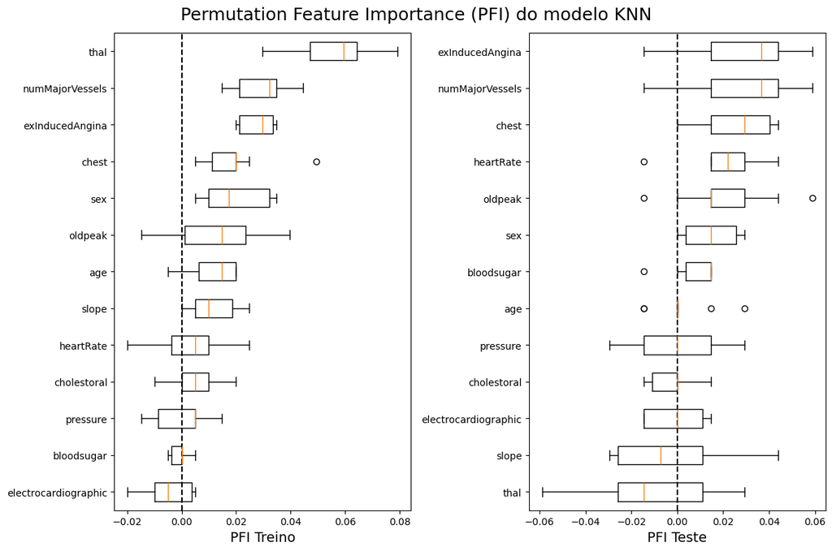

```python
fig, (ax1, ax2) = plt.subplots(1, 2, figsize=(12, 8))

plot_permutation_importance(clfs['knn_geral'], X_train_scaled, y_train, ax1)
ax1.set_xlabel("PFI Treino", fontsize=14)
plot_permutation_importance(clfs['knn_geral'], X_test_scaled, y_test, ax2)
ax2.set_xlabel("PFI Teste", fontsize=14)

fig.suptitle(
    f"Permutation Feature Importance (PFI) do modelo {clfs_names['knn_geral']}",
    fontsize=18
)
_ = fig.tight_layout()
```

## 4.2. Árvore de Decisão

```python
clfs_names['dt_geral'] = "Árvore de Decisão"
clfs['dt_geral'] = DecisionTreeClassifier(
    random_state=42,
    criterion='entropy',
    max_depth=5,
    min_samples_leaf=5
).fit(X_train, y_train)
```

```python
y_preds_train['dt_geral'] = clfs['dt_geral'].predict(X_train)
y_preds_test['dt_geral'] = clfs['dt_geral'].predict(X_test)
```

```python
# Train
print(classification_report(y_train, y_preds_train['dt_geral']))
```

```
              precision    recall  f1-score   support

           0       0.90      0.94      0.92       114
           1       0.92      0.86      0.89        88

    accuracy                           0.91       202
   macro avg       0.91      0.90      0.90       202
weighted avg       0.91      0.91      0.91       202
```

```python
# Test
print(classification_report(y_test, y_preds_test['dt_geral']))
```

```
              precision    recall  f1-score   support

           0       0.66      0.81      0.72        36
           1       0.71      0.53      0.61        32

    accuracy                           0.68        68
   macro avg       0.68      0.67      0.67        68
weighted avg       0.68      0.68      0.67        68
```

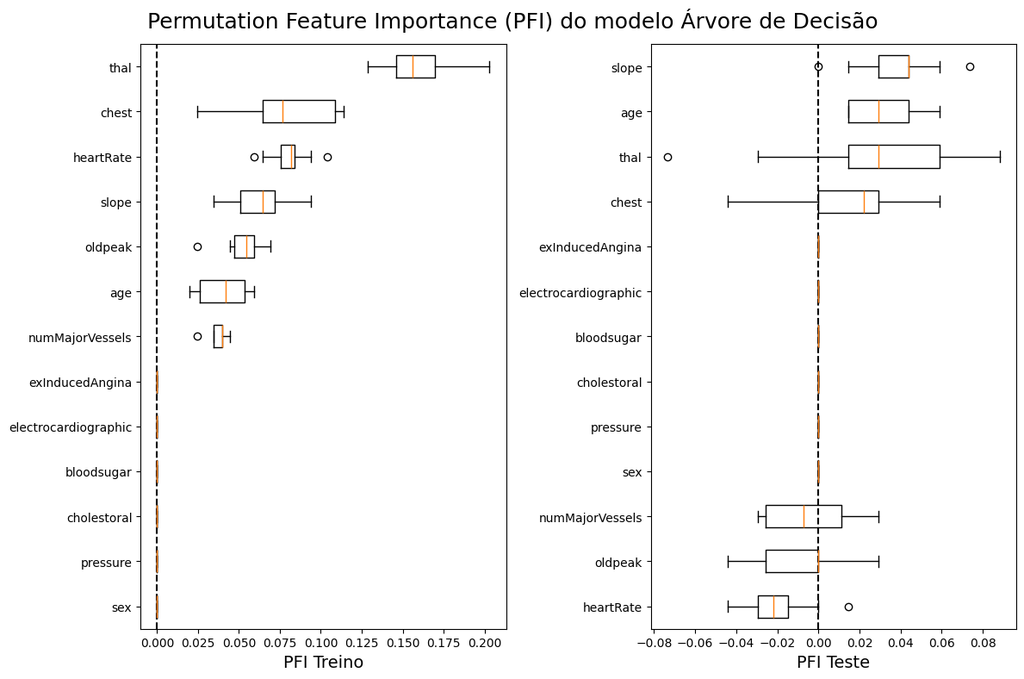

```python
fig, (ax1, ax2) = plt.subplots(1, 2, figsize=(12, 8))

plot_permutation_importance(clfs['dt_geral'], X_train, y_train, ax1)
ax1.set_xlabel("PFI Treino", fontsize=14)
plot_permutation_importance(clfs['dt_geral'], X_test, y_test, ax2)
ax2.set_xlabel("PFI Teste", fontsize=14)

fig.suptitle(
    f"Permutation Feature Importance (PFI) do modelo {clfs_names['dt_geral']}",
    fontsize=18
)
_ = fig.tight_layout()
```

## 4.3. Random Forest

```python
clfs_names['rf_geral'] = "Random Forest"
clfs['rf_geral'] = RandomForestClassifier(
    n_estimators=20,
    criterion='entropy',
    max_depth=5,
    min_samples_leaf=5,
    random_state=42
).fit(X_train, y_train)
```

```python
y_preds_train['rf_geral'] = clfs['rf_geral'].predict(X_train)
y_preds_test['rf_geral'] = clfs['rf_geral'].predict(X_test)
```

```python
# Train
print(classification_report(y_train, y_preds_train['rf_geral']))
```

```
              precision    recall  f1-score   support

           0       0.92      0.96      0.94       114
           1       0.94      0.89      0.91        88

    accuracy                           0.93       202
   macro avg       0.93      0.92      0.92       202
weighted avg       0.93      0.93      0.93       202
```

```python
# Test
print(classification_report(y_test, y_preds_test['rf_geral']))
```

```
              precision    recall  f1-score   support

           0       0.72      0.92      0.80        36
           1       0.86      0.59      0.70        32

    accuracy                           0.76        68
   macro avg       0.79      0.76      0.75        68
weighted avg       0.79      0.76      0.76        68
```

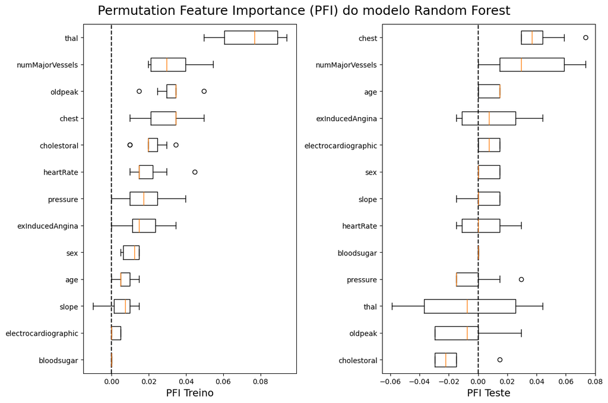

```python
fig, (ax1, ax2) = plt.subplots(1, 2, figsize=(12, 8))

plot_permutation_importance(clfs['rf_geral'], X_train, y_train, ax1)
ax1.set_xlabel("PFI Treino", fontsize=14)
plot_permutation_importance(clfs['rf_geral'], X_test, y_test, ax2)
ax2.set_xlabel("PFI Teste", fontsize=14)

fig.suptitle(
    f"Permutation Feature Importance (PFI) do modelo {clfs_names['rf_geral']}",
    fontsize=18
)
_ = fig.tight_layout()
```

# 5. Modelos Específicos de Gênero (2)

*Voltar à Tabela de Conteúdos*

```python
df_test = pd.concat([X_test, y_test], axis=1)
df_test_sex_0 = df_test[df_test.sex == 0].reset_index(drop=True)
df_test_sex_1 = df_test[df_test.sex == 1].reset_index(drop=True)
```

```python
X_test_sex_0 = df_test_sex_0[list(X_test.columns)]
y_test_sex_0 = df_test_sex_0[['class']]

X_test_sex_1 = df_test_sex_1[list(X_test.columns)]
y_test_sex_1 = df_test_sex_1[['class']]
```

```python
X_test_scaled_sex_0 = pd.DataFrame(scaler.transform(X_test_sex_0), columns=X_test_sex_0.columns)
X_test_scaled_sex_1 = pd.DataFrame(scaler.transform(X_test_sex_1), columns=X_test_sex_1.columns)
```

## 5.1. KNN

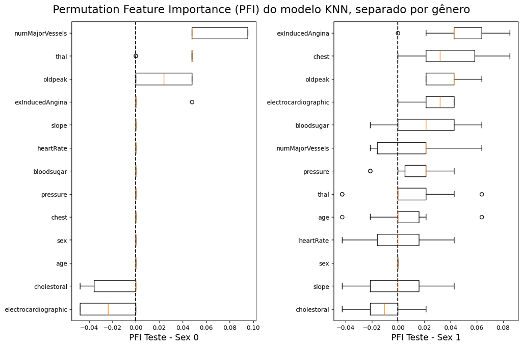

```python
fig, (ax1, ax2) = plt.subplots(1, 2, figsize=(12, 8))

plot_permutation_importance(clfs['knn_geral'], X_test_scaled_sex_0, y_test_sex_0, ax1)
ax1.set_xlabel("PFI Teste - Sex 0", fontsize=14)

plot_permutation_importance(clfs['knn_geral'], X_test_scaled_sex_1, y_test_sex_1, ax2)
ax2.set_xlabel("PFI Teste - Sex 1", fontsize=14)

fig.suptitle(
    f"Permutation Feature Importance (PFI) do modelo {clfs_names['knn_geral']}, separado por gênero",
    fontsize=18
)
_ = fig.tight_layout()
```

## 5.2. Árvore de Decisão

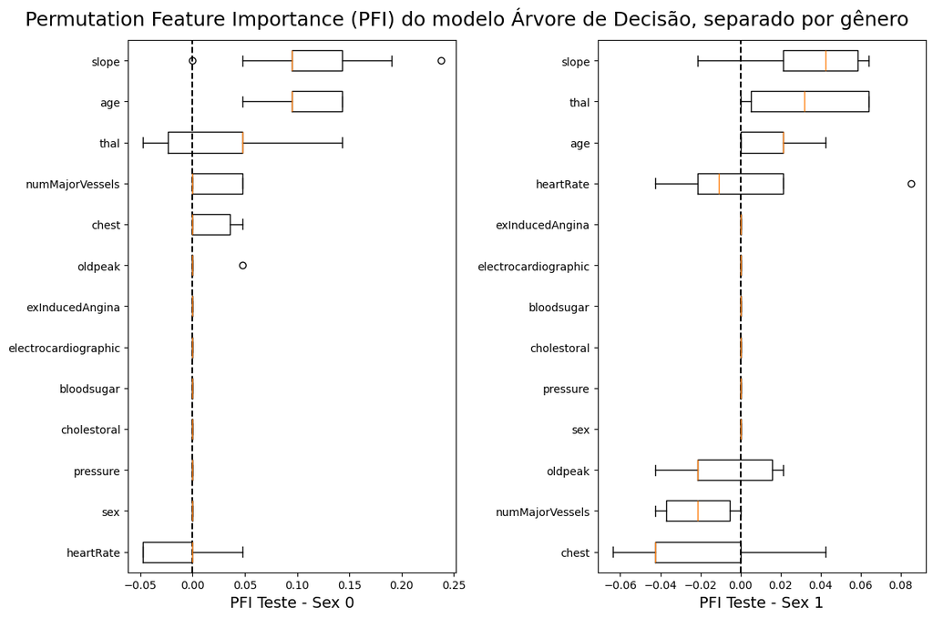

```python
fig, (ax1, ax2) = plt.subplots(1, 2, figsize=(12, 8))

plot_permutation_importance(clfs['dt_geral'], X_test_sex_0, y_test_sex_0, ax1)
ax1.set_xlabel("PFI Teste - Sex 0", fontsize=14)

plot_permutation_importance(clfs['dt_geral'], X_test_sex_1, y_test_sex_1, ax2)
ax2.set_xlabel("PFI Teste - Sex 1", fontsize=14)

fig.suptitle(
    f"Permutation Feature Importance (PFI) do modelo {clfs_names['dt_geral']}, separado por gênero",
    fontsize=18
)
_ = fig.tight_layout()
```

## 5.3. Random Forest

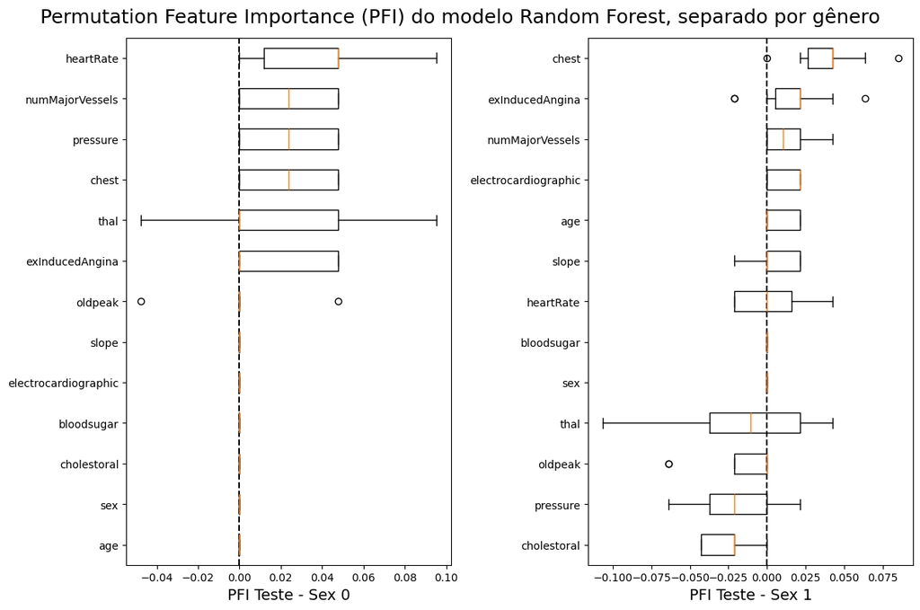

```python
fig, (ax1, ax2) = plt.subplots(1, 2, figsize=(12, 8))

plot_permutation_importance(clfs['rf_geral'], X_test_sex_0, y_test_sex_0, ax1)
ax1.set_xlabel("PFI Teste - Sex 0", fontsize=14)

plot_permutation_importance(clfs['rf_geral'], X_test_sex_1, y_test_sex_1, ax2)
ax2.set_xlabel("PFI Teste - Sex 1", fontsize=14)

fig.suptitle(
    f"Permutation Feature Importance (PFI) do modelo {clfs_names['rf_geral']}, separado por gênero",
    fontsize=18
)
_ = fig.tight_layout()
```